# Homework3a

yi Chen

9/18/2018

# Homework 3a

Yi Chen

YC3356

yc3356@columbia.edu

## a) stan program

The result is not identical (I have tried not to use the prior first, but the result is very bad).

Thus, we should use some prior information. I choose to use the cauchy distribution since it is not so strong and usually give a more robust result.

data{

int<lower=0> N;

vector[N] x;

vector[N] y;

}

parameters{

real<lower=0> a;

real<lower=0> b;

real<lower=0> sigma;

}

model{

a ~ cauchy(2,1);

b ~ cauchy(3,1);

y ~ normal(0,sigma ./ (a+b*x));

}

## b) simulate the fake data

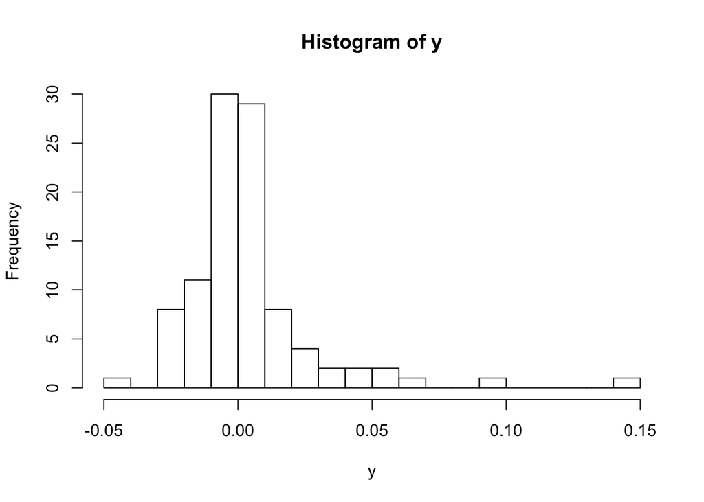

```r
N <- 100
x <- runif(N,0,10)
a <- 2
b <- 3
sigma <- 0.2
error <- rnorm(N,0,sigma)
y <- (1/(a+b*x)) * error
data <- list(N=N,x=x,y=y)
hist(y,breaks = 20)
```

# c) fit the stan model with simulated data

```r
library(rstan)
options(mc.cores = parallel::detectCores())
rstan_options(auto_write = TRUE)
fit <- stan('./homework_3a.stan',data=data)
```

[output not shown]

[output cut: 164 more lines]

[output not shown]

```r
print(fit)
```

```
## Inference for Stan model: homework_3a.
## 4 chains, each with iter=2000; warmup=1000; thin=1;
## post-warmup draws per chain=1000, total post-warmup draws=4000.
##
##                mean       se_mean            sd   2.5%    25%    50%
## a      3.350000e+00  5.100000e-01  1.403000e+01   0.78   1.78   2.29
## b     7.786096e+149 3.247887e+149 2.054144e+151   1.81   2.99   3.84
## sigma 4.345633e+148 4.299081e+148 1.155547e+150   0.12   0.20   0.26
## lp__   3.777600e+02  1.390000e+00  3.440000e+00 369.05 377.13 379.10
##          75%         97.5% n_eff Rhat
## a       2.96  8.660000e+00   769 1.00
## b       6.54 1.126570e+143  4000 1.00
## sigma   0.42 6.438095e+141   722 1.00
## lp__  380.10  3.808700e+02     6 1.84
##
## Samples were drawn using NUTS(diag_e) at Thu Sep 20 13:55:42 2018.
## For each parameter, n_eff is a crude measure of effective sample size,
## and Rhat is the potential scale reduction factor on split chains (at
## convergence, Rhat=1).
```

# d) draw the praph

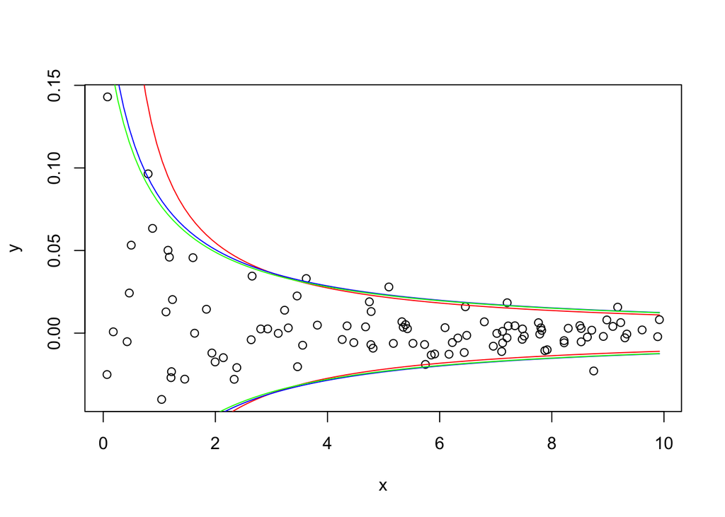

```r
## if we fit the model with mean
results <- extract(fit)
plot(x,y)
a_mean <- mean(results$a)
b_mean <- mean(results$b)
sigma_mean <- mean(results$sigma)
a_median <- median(results$a)
b_median <- median(results$b)
sigma_median <- median(results$sigma)
## red lines are the posterior mean
curve(1.96*(1/(a_mean+b_mean*x))*sigma_mean,add = T,col='red')
curve(-1.96*(1/(a_mean+b_mean*x))*sigma_mean,add = T,col='red')
# blue lines are the posterior median
curve(1.96*(1/(a_median+b_median*x))*sigma_median,add = T,col='blue')
curve(-1.96*(1/(a_median+b_median*x))*sigma_median,add = T,col='blue')
# green lines are the true value
curve(1.96*(1/(2+3*x))*0.2,add=T,col='green')
curve(-1.96*(1/(2+3*x))*0.2,add=T,col='green')
```

**Note**

In this plot I draw the 95% upder bound and lower bound for the true value, posterior mean and posterior median for a, b and sigma.

The red line is based on posterior mean, the blue line is based on posterior median and the green line is the true value.

As we can see, almost all points are in this range and these three line overlap with each other.

# e)

In this problem there are sever things that I think is very important:

1. The prior information is need. Otherwise, given such a small sample size, it is impossible to get a good estimation.
2. In this problem, we are not care about the mean of distribution anymore. All the parameters are related to variance.